# Daily-assignments

# Question 1:

## This dataset shows 153 different recordings for ozone levels, solar radiation levels, wind speed, temperature, and month and day for each record. The summary shows various means, mins, etc for each variable.

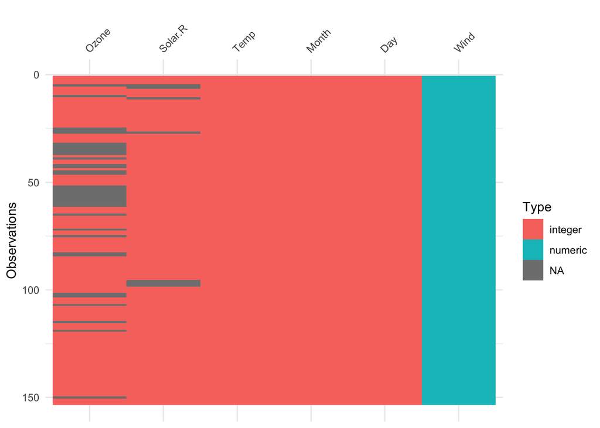

```r
library(visdat)
vis_dat(airquality)
```

```r
str(airquality)
```

```
'data.frame':   153 obs. of  6 variables:
 $ Ozone  : int  41 36 12 18 NA 28 23 19 8 NA ...
 $ Solar.R: int  190 118 149 313 NA NA 299 99 19 194 ...
 $ Wind   : num  7.4 8 12.6 11.5 14.3 14.9 8.6 13.8 20.1 8.6 ...
 $ Temp   : int  67 72 74 62 56 66 65 59 61 69 ...
 $ Month  : int  5 5 5 5 5 5 5 5 5 5 ...
 $ Day    : int  1 2 3 4 5 6 7 8 9 10 ...
```

```r
summary(airquality)
```

```
     Ozone           Solar.R           Wind             Temp
 Min.   :  1.00   Min.   :  7.0   Min.   : 1.700   Min.   :56.00
 1st Qu.: 18.00   1st Qu.:115.8   1st Qu.: 7.400   1st Qu.:72.00
 Median : 31.50   Median :205.0   Median : 9.700   Median :79.00
 Mean   : 42.13   Mean   :185.9   Mean   : 9.958   Mean   :77.88
 3rd Qu.: 63.25   3rd Qu.:258.8   3rd Qu.:11.500   3rd Qu.:85.00
 Max.   :168.00   Max.   :334.0   Max.   :20.700   Max.   :97.00
 NA's   :37       NA's   :7
     Month            Day
 Min.   :5.000   Min.   : 1.0
 1st Qu.:6.000   1st Qu.: 8.0
 Median :7.000   Median :16.0
 Mean   :6.993   Mean   :15.8
 3rd Qu.:8.000   3rd Qu.:23.0
 Max.   :9.000   Max.   :31.0
```

```r
shapiro.test(airquality$Ozone)
```

```
    Shapiro-Wilk normality test

data:  airquality$Ozone
W = 0.87867, p-value = 2.79e-08
```

```r
shapiro.test(airquality$Temp)
```

```
    Shapiro-Wilk normality test

data:  airquality$Temp
W = 0.97617, p-value = 0.009319
```

```r
shapiro.test(airquality$Solar.R)
```

```
    Shapiro-Wilk normality test

data:  airquality$Solar.R
W = 0.94183, p-value = 9.492e-06
```

```r
shapiro.test(airquality$Wind)
```

```
    Shapiro-Wilk normality test

data:  airquality$Wind
W = 0.98575, p-value = 0.1178
```

# 3:

## A Shapiro-Wilk test is utilized to test if a dataset follows normal distribution.

# 4:

## The null hypothesis for a Shapiro-Wilk test is: The data are normally distributed. The alternative hypothesis for this test is: The data are not normally distributed.

# 5:

## If a p-value is > 0.05, we fail to reject the null and therefore conclude that the data are likely normally distributed. If the p-value is less than or equal to 0.05, we reject the null and conclude that the data are likely not normally distributed. So, according to their respective p-values, only the variable Wind is normally distributed. The variables Solar radiation, Temp, and Ozone all deviate from a normal distribution.

```r
library(dplyr)
airquality <- airquality %>%
  mutate(Season = case_when(
    Month %in% c(11, 12, 1) ~ "Winter",
    Month %in% c(2, 3, 4) ~ "Spring",
    Month %in% c(5, 6, 7) ~ "Summer",
    Month %in% c(8, 9, 10) ~ "Fall"
))
```

# 7:

## There are 92 observations in summer and 61 observations in fall.

```r
season_observations <- table(airquality$Season)
print(season_observations)
```

```
  Fall Summer
    61     92
```

```r
library(tidymodels)
library(recipes)
recipe_obj <- recipe(~ ., data = airquality) %>%
  step_impute_mean(all_integer()) %>%
  step_range(all_of(c("Wind", "Solar.R", "Temp")), min = 0, max = 1)
```

# 9:

## Data is normalized to prevent biases in a model, increase predictability, increase performance of algorithms and analyses, and ensure overall consistency.

#10: ## The function “step_impute_mean” can be used to impute missing values with the mean value.

```r
prepped_obj <- prep(recipe_obj, training = airquality)
baked_onj <- bake(prepped_obj, new_data = airquality)
```

# 12:

## It is neccessary to prep a dataset to first estimate which perameters will be used in the new datset based on training data. This determines the scale to be used. It is neccessary to bake a dataset because this is the step that actually applies the new parameters to the new dataset.

```r
model <- lm(Ozone ~ ., data = baked_onj)
summary(model)
```

```
Call:
lm(formula = Ozone ~ ., data = baked_onj)

Residuals:
    Min      1Q  Median      3Q     Max
-41.921 -13.394  -3.124   9.633  97.861

Coefficients:
             Estimate Std. Error t value Pr(>|t|)
(Intercept)   55.1723    21.9095   2.518  0.01287 *
Solar.R       18.5665     6.7065   2.768  0.00636 **
Wind         -50.1444    10.2599  -4.887 2.66e-06 ***
Temp          60.8172     9.8149   6.196 5.59e-09 ***
Month         -4.7076     2.6722  -1.762  0.08021 .
Day            0.2766     0.1932   1.432  0.15432
SeasonSummer  -8.8954     7.1777  -1.239  0.21722
---
Signif. codes:  0 '***' 0.001 '**' 0.01 '*' 0.05 '.' 0.1 ' ' 1

Residual standard error: 20.74 on 146 degrees of freedom
Multiple R-squared:  0.4979,    Adjusted R-squared:  0.4773
F-statistic: 24.13 on 6 and 146 DF,  p-value: < 2.2e-16
```

#14: ## The model’s positive coefficient for Solar.R and Temp means that Ozone levels have a positive correlation with solar radiation and temperature: as radiation or temp increase, ozone levels will also increase. The negative coefficient for wind and month means that these two variables have a negative correlation with ozone: as wind increases or months become later in the year, the ozone levels will decrease. The adjusted R-squared value of 0.4773 means that about 48% of the ozone variability can be explained by the predictor variables. Since the p-values of solar radiation, wind, and temperature are less than 0.05, these predictor variables have a statistically significant effect on ozone. Since all other variables have a p-value greater than 0.05, these variables do not have a statistically significant effect on ozone.

```r
library(tidyverse)
a_data <- broom::augment(model, baked_onj)
head(a_data)
```

```
# A tibble: 6 × 13
  Ozone Solar.R  Wind  Temp Month   Day Season .fitted  .resid   .hat .sigma
  <int>   <dbl> <dbl> <dbl> <int> <int> <fct>    <dbl>   <dbl>  <dbl>  <dbl>
1    41   0.560 0.3   0.268     5     1 Summer   34.7    6.32  0.0587   20.8
2    36   0.339 0.332 0.390     5     2 Summer   36.7   -0.701 0.0521   20.8
3    12   0.434 0.574 0.439     5     3 Summer   29.6  -17.6   0.0449   20.8
4    18   0.936 0.516 0.146     5     4 Summer   24.3   -6.26  0.0665   20.8
5    42   0.547 0.663 0         5     5 Summer    1.03  41.0   0.0596   20.5
6    28   0.547 0.695 0.244     5     6 Summer   14.6   13.4   0.0409   20.8
# ℹ 2 more variables: .cooksd <dbl>, .std.resid <dbl>
```

```r
library(ggplot2)
histo_plot <- ggplot(a_data, aes(x = .resid)) +
  geom_histogram(fill = "red") +
  labs(title = "Residuals Histogram") +
  theme_minimal()
```

```r
qq_plot <- ggplot(a_data, aes(sample = .resid)) +
  geom_qq() +
  geom_abline(intercept = 0, slope = 1, color = "red")
  labs(title = "Residuals Q-Q Plot") +
  theme_minimal()
```

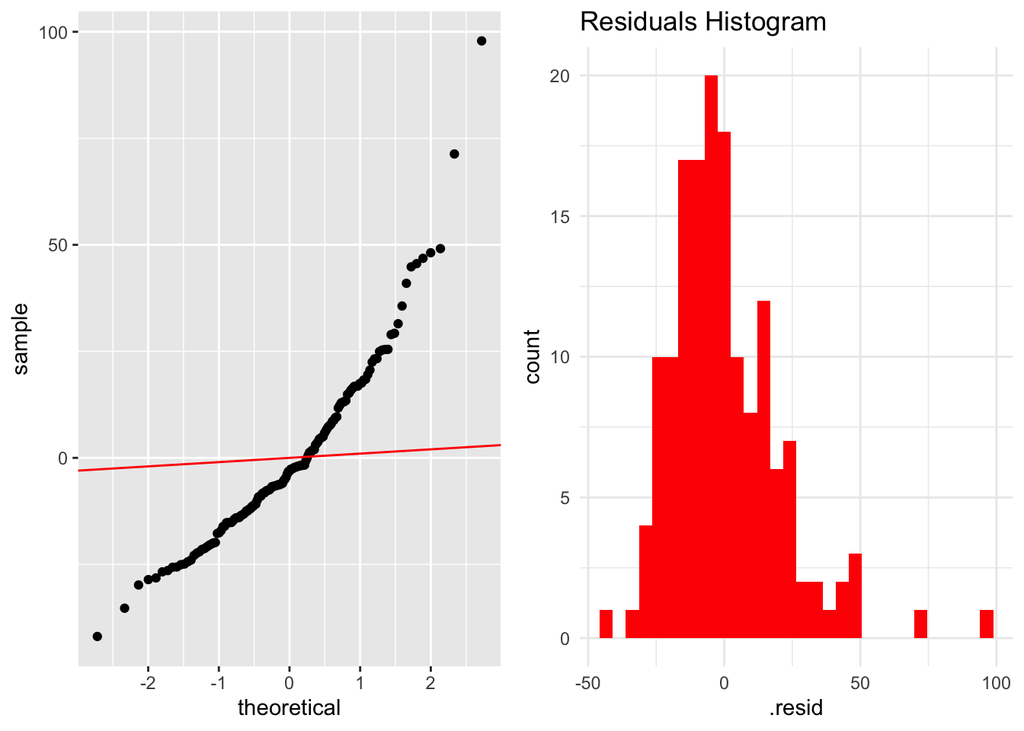

```r
library(ggpubr)
ggarrange(qq_plot, histo_plot, ncol = 2, nrow = 1)
```

# 17:

## By arranging the histogram and qq plots next to each other, I see that the residuals data are not normally distributed (as seen in the qq plot, since the plotted points do not alight with the 45 degree angle line), rather, these data are slightly right-skewed (as seen on the histogram).

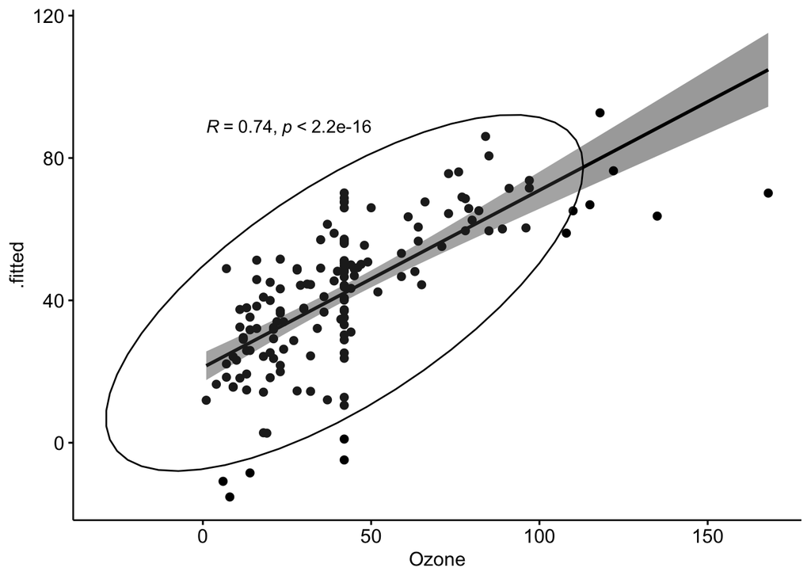

```r
ggscatter(a_data, x = "Ozone", y = ".fitted",
          add = "reg.line", conf.int = TRUE,
          cor.coef = TRUE, cor.method = "spearman",
          ellipse = TRUE)
```

# 19: